# **DEEP LEARNING PROJECT**

**Sergio Tambè** *and* **Chiara Santaera**

## **Introduction**

**Verbal communication** can be hindered in **noisy** environments or to address technical **limitations** in video recordings with **low-quality audio**, such as interpreting surveillance videos.

It can also find **applications** in:

- Protecting against audio **deepfakes** (through lip-reading)
- in **human-computer interaction**, allowing devices to be controlled without speaking.

Further developments could include integration into **augmented/virtual reality**, social **robotics**, and the creation of lifelike **avatars** capable of faithfully reproducing speech **movements**.

In this context, **Lip Reading** emerges as a vital tool. This project focuses on the analysis of videos *cropped* exclusively around the lips, excluding audio. This approach is *fundamental* in training a **neural network model** focused on *lip movements*.

## 1. **Exploratory Data Analysis (EDA)**

In this initial phase, we focus on the preliminary analysis of the dataset and the setup of the working environment. The primary goal is to transform raw video files into a structured format, allowing us to extract statistical insights and streamline the data feeding process for the neural network.

In the following cell, we import the needed libraries for this analysis.

```python
import os
import cv2
import pandas as pd
import numpy as np
import matplotlib.pyplot as plt
import seaborn as sns
import torch
from torch.utils.data import Dataset, DataLoader
```

The **Data Exploration** begins by scanning the dataset directory. Since the dataset is organized into subfolders, we use os.walk to navigate and extract the file.

For every video, we collect the following attributes:

- **User**: Extracted from the subfolder name (the subject's identity).
- **Label**: Extracted from the filename (the word being spoken), normalized to uppercase.
- **Frames**: The total temporal length of the video.
- **Resolution (res)**: The spatial dimensions (*Width x Height*).
- **FPS**: The fluidity of the recording (Frames Per Second).

This metadata is compiled into a **list** and subsequently converted into a **DataFrame**.

```python
dataset_path = "C:/Users/sergi/Desktop/3semestre/deep learning/progetto/video_cropped/video_cropped"
data_list = [] # Inizialize list

for root, dirs, files in os.walk(dataset_path): # 'os.walk' surf in the subfolders
    for file_name in files:
        if file_name.lower().endswith('.mp4'): # use '.lower()' to select mp4 and MP4 extension

            # 1. Estraiamo il nome della cartella corrente, che contiene il nome di chi ha fatto il video
            # 'root' è il percorso completo, 'basename' prende solo l'ultima parte
            user = os.path.basename(root)

            # 2. Rimuoviamo l'estensione ed estraiamo la label
            name_without_ext = os.path.splitext(file_name)[0]
            label = name_without_ext.split('_')[-1].upper()

            video_path = os.path.join(root, file_name)
            cap = cv2.VideoCapture(video_path)

            frame_count = int(cap.get(cv2.CAP_PROP_FRAME_COUNT))
            fps = cap.get(cv2.CAP_PROP_FPS)
            width = int(cap.get(cv2.CAP_PROP_FRAME_WIDTH))
            height = int(cap.get(cv2.CAP_PROP_FRAME_HEIGHT))
            cap.release()

            # 3. Riempiamo la lista
            data_list.append({
                'user': user,
                'file': file_name,
                'label': label,
                'frames': frame_count,
                'res': f"{width}x{height}",
                'fps': fps
            })

df = pd.DataFrame(data_list)

print(f"Video founded: {len(df)}")
print(df.head())
```

```
Video founded: 650
      user                          file label  frames      res    fps
0  Adriano  VID_20240425_123033_FLAG.mp4  FLAG      65  256x128  29.95
1  Adriano  VID_20240425_123038_FLAG.mp4  FLAG      57  256x128  29.95
2  Adriano  VID_20240425_123042_FLAG.mp4  FLAG      54  256x128  29.95
3  Adriano  VID_20240425_123047_FLAG.mp4  FLAG      50  256x128  29.95
4  Adriano  VID_20240425_123051_FLAG.mp4  FLAG      59  256x128  29.95
```

In the next part we perform a **visual analysis** focusing on two main aspects:

- **Label Distribution**: A bar plot to identify potential class imbalances among the words.
- **Frame Distribution**: Box plots to analyze the distribution of frame counts across different subjects and words, helping us justify the choice of our padding strategy.

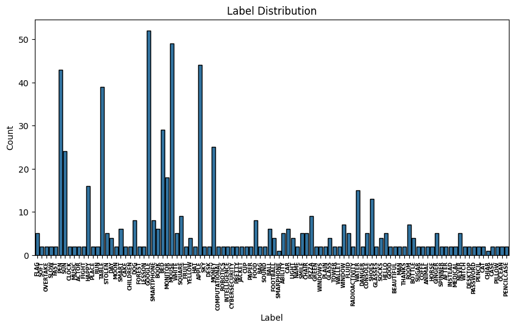

```python
# 1. Distribuzione delle classi
plt.figure(figsize=(10, 5))
sns.countplot(data=df, x='label', edgecolor='black')
plt.xticks(rotation=90, fontsize=6, fontweight='bold')
plt.title('Label Distribution')
plt.xlabel('Label')
plt.ylabel('Count')
plt.show()
```

```python
counts = df['label'].value_counts()
print(counts)
```

```
label
GOOGLE        52
MOUSE         49
APPLE         44
PEN           43
TABLE         39
              ..
CASE           2
PENCILCASE     2
PILLOW         2
SMARPHONE      1
CHIAR          1
Name: count, Length: 102, dtype: int64
```

By looking at the barplot we can notice the presence of **"label noise"**, 'SMARPHONE' and 'CHIAR' appear only once.

We modify manually these labels into **'SMARTPHONE'** and **'CHAIR'**.

This step is crucial because it consolidates these samples into their correct categories, preventing the model from creating redundant and underpopulated classes.

```python
corrections = {
    'CHIAR': 'CHAIR',
    'SMARPHONE': 'SMARTPHONE',
}
df['label'] = df['label'].replace(corrections)
```

```python
counts = df['label'].value_counts()
print(counts)
```

```
label
GOOGLE        52
MOUSE         49
APPLE         44
PEN           43
TABLE         39
              ..
CAT            2
CASE           2
PILLOW         2
OCEAN          2
PENCILCASE     2
Name: count, Length: 100, dtype: int64
```

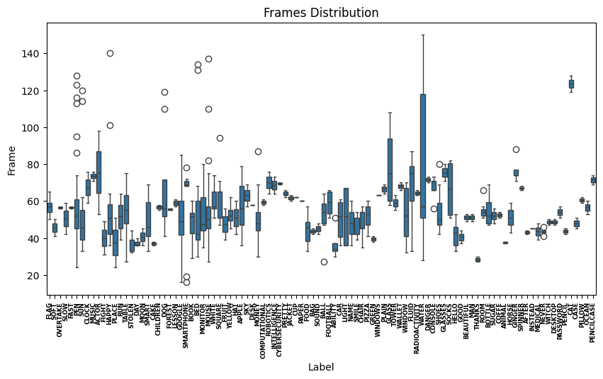

```
           frames         fps
count  650.000000  650.000000
mean    55.086154   30.953738
std     18.454591    6.002267
min     16.000000   24.350000
25%     43.000000   29.950000
50%     53.000000   29.950000
75%     63.000000   29.950000
max    150.000000   60.000000
```

```python
# 2. Distribuzione numero di frame
plt.figure(figsize=(10, 5))
sns.boxplot(data=df, x='label', y='frames')
plt.xticks(rotation=90, fontsize=6, fontweight='bold')
plt.title('Frames Distribution')
plt.xlabel('Label')
plt.ylabel('Frame')
plt.show()

print(df.describe())
```

After analyzing the **Frames Distribution**, we observed that while the absolute maximum is 150 frames, most samples fall within 100 frames.

Instead of using the global maximum of 150, we set our standardized length to **$T$ = 82**, that is the upper limit for the 'SOCKS' class.

```python
# Calcoliamo il massimo esatto per la parola 'GLASS'
max_frames = df[df['label'] == 'SOCKS']['frames'].max()

# Contiamo quanti video in totale superano questa soglia
videos_above = df[df['frames'] > max_frames]
num_above = len(videos_above)
percentage_above = (num_above / len(df)) * 100

print(f"Frames: {max_frames}")
print(f"Video missed (>{max_frames}): {percentage_above:.2f}%")
print(df.describe())
```

[output not shown]

This decision offers the next main advantages:

- **Coverage:** This limit effectively covers the majority of the samples across almost all classes.
- **Impact of Truncation:** Only **4.77%** of the video sequences exceed this limit. For these samples, the truncation primarily affects the final frames, which in most recordings contain redundant or silent lip movements.
- **Computational Efficiency:** Reducing the sequence length from 150 to 82 frames allows for a significantly faster training process and more efficient memory management, without compromising the core linguistic features of the lip dynamics.

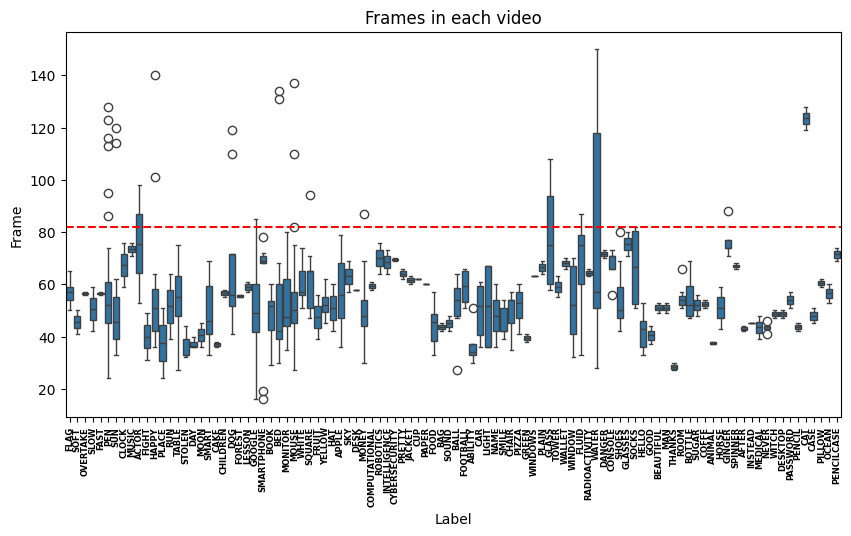

```python
# 2. Applichiamo la "normalizzazione" (simulazione del padding nel DataFrame)
# Creiamo una nuova colonna dove ogni valore viene portato a 82
df['frames_padded'] = max_frames

# 3. Rappresentazione del Boxplot con linea che rappresenta
plt.figure(figsize=(10, 5))

sns.boxplot(data=df, x='label', y='frames')
plt.xticks(rotation=90, fontsize=6, fontweight='bold')
plt.axhline(y=max_frames, color='red', linestyle='--', label=f'Target Padding ({max_frames})')
plt.title('Frames in each video')
plt.xlabel('Label')
plt.ylabel('Frame')

plt.show()
```

## **Data Splitting Strategy**

Since the videos are divided by **user** folders (Adriano, Alessandra, etc.), we don't randomly divide the videos between the training set and the validation set, but instead apply a **stratification by user**, placing some users' folders in the Training set and other users' folders in the Validation set.

This ensures that the model truly learns to **read lips** regardless of who speaks, for example Adriano says 'FLAG' 5 times and 'SOFT' only 2 times, so the model could classify in 'FLAG' when it sees a video of Adriano.

This **approach** will make the model much more **robust**. Then, the folders by user will be randomly divided into the **Training** and **Validation** sets (80% - 20%).

```python
np.random.seed(322) #
user = df['user'].unique() # Creiamo la lista unica di tutti gli users

# 3. Mescoliamo la lista dei soggetti in modo casuale
# Creiamo una copia per non alterare l'array originale se servisse altrove
soggetti_shuffled = np.copy(user)
np.random.shuffle(soggetti_shuffled)

# 4. Dividiamo la lista in Train e Validation (i primi 9 per validation, i restanti 34 per training)
val_subjects = soggetti_shuffled[:9]
train_subjects = soggetti_shuffled[9:]

# 5. Creiamo quindi i due DataFrame filtrando per users
df_val = df[df['user'].isin(val_subjects)]
df_train = df[df['user'].isin(train_subjects)]

# 6. Verifichiamo di mantenere una divisione 80%-20%
print(f"Users randomly choosen for Validation Set: \n{val_subjects}")
print("-" * 40)
print(f"Video that fall in Training Set:   {len(df_train)} ({len(train_subjects)} Users) and 80% of 650 is {int(650/100*80)}")
print(f"Video that fall in Validation Set: {len(df_val)} ( {len(val_subjects)} Users) and 20% of 650 is {int(650/100*20)}")
print("-" * 40)
```

```
Users randomly choosen for Validation Set:
['Vincenzo' 'Rachele' 'Mattia' 'SimoneO' 'Francesca' 'GiuseppeV' 'Jacopo'
 'AlessandroS' 'StefanoM']
----------------------------------------
Video that fall in Training Set:   520 (34 Users) and 80% of 650 is 520
Video that fall in Validation Set: 130 ( 9 Users) and 20% of 650 is 130
----------------------------------------
```

In this way we divide the dataset into 80% - 20%, but respecting the '**Stratification by User**'